# Portfolio assignment 7

15 min: Look at the histogram of at least 2 columns with numerical data in the dataset that you chose in portfolio assignment 4. Do you recognise the distribution? Does it look like a uniform or normal distribution or something else? If it doesn't look like a uniform or normal distribution, take a quick look here to see if you can find the distribution shape: https://www.itl.nist.gov/div898/handbook/eda/section3/eda366.htm

import pandas as pd

```python
data = pd.read_csv('Data.csv')
```

```python
data
```

|  | Country | League | Club | Player Names | Matches_Played | Substitution | Mins | Goals | xG | xG Per Avg Match | Shots | OnTarget | Shots Per Avg Match | On Target Per Avg Match | Year |
| --- | --- | --- | --- | --- | --- | --- | --- | --- | --- | --- | --- | --- | --- | --- | --- |
| 0 | Spain | La Liga | (BET) | Juanmi Callejon | 19 | 16 | 1849 | 11 | 6.62 | 0.34 | 48 | 20 | 2.47 | 1.03 | 2016 |
| 1 | Spain | La Liga | (BAR) | Antoine Griezmann | 36 | 0 | 3129 | 16 | 11.86 | 0.36 | 88 | 41 | 2.67 | 1.24 | 2016 |
| 2 | Spain | La Liga | (ATL) | Luis Suarez | 34 | 1 | 2940 | 28 | 23.21 | 0.75 | 120 | 57 | 3.88 | 1.84 | 2016 |
| 3 | Spain | La Liga | (CAR) | Ruben Castro | 32 | 3 | 2842 | 13 | 14.06 | 0.47 | 117 | 42 | 3.91 | 1.40 | 2016 |
| 4 | Spain | La Liga | (VAL) | Kevin Gameiro | 21 | 10 | 1745 | 13 | 10.65 | 0.58 | 50 | 23 | 2.72 | 1.25 | 2016 |
| ... | ... | ... | ... | ... | ... | ... | ... | ... | ... | ... | ... | ... | ... | ... | ... |
| 655 | Netherlands | Eredivisie | (UTR) | Gyrano Kerk | 24 | 0 | 2155 | 10 | 7.49 | 0.33 | 50 | 18 | 2.20 | 0.79 | 2020 |
| 656 | Netherlands | Eredivisie | (AJA) | Quincy Promes | 18 | 2 | 1573 | 12 | 9.77 | 0.59 | 56 | 30 | 3.38 | 1.81 | 2020 |
| 657 | Netherlands | Eredivisie | (PSV) | Denzel Dumfries | 25 | 0 | 2363 | 7 | 5.72 | 0.23 | 45 | 14 | 1.81 | 0.56 | 2020 |
| 658 | Netherlands | Eredivisie | None | Cyriel Dessers | 26 | 0 | 2461 | 15 | 14.51 | 0.56 | 84 | 43 | 3.24 | 1.66 | 2020 |
| 659 | Netherlands | Eredivisie | (PSV) | Cody Gakpo | 14 | 11 | 1557 | 7 | 4.43 | 0.27 | 38 | 15 | 2.32 | 0.92 | 2020 |

660 rows × 15 columns

```python
#Numerical
```

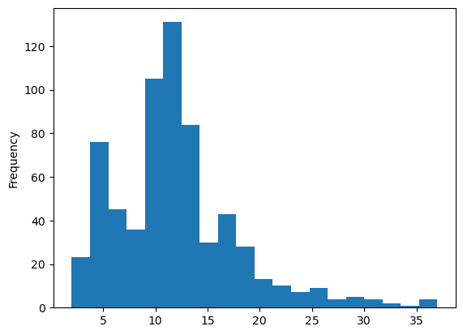

```python
data["Goals"].plot(kind='hist', bins = 20) # Goals
```

# Dit is een histogram voor de aantal doelpunten die iedere speler heeft gemaakt.

De distributie van deze histogram heeft een Lognormal Distribution. Wat ik uit de histogram kan halen, is dat de piek van de histogram in het begin een hoge y-waarde heeften het snel omhoog gaat. Vanaf de piek daalt het snel, maar de daling wordt naarmate het eind minder steil. Daarom is de de distributie een Lognormaal.

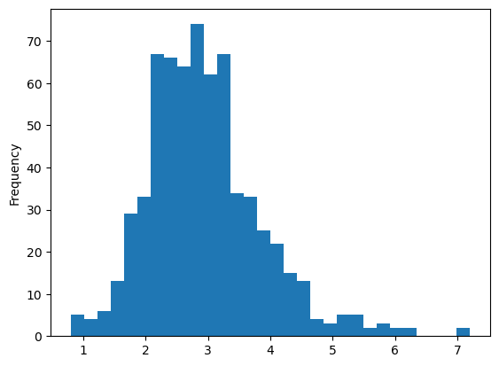

```python
data["Shots Per Avg Match"].plot(kind='hist', bins = 30) # Shots Per Avg Match
```

# Dit is een histogram voor het gemiddelde aantal schoten een speler heeft gemaakt per wedstrijd heeft genomen.

De distributie van deze histogram heeft een Binomial Distribution. De piek van de histogram leunt meer links van centrum af. Rechts van de piek daalt de frequentie minder snel naarmate de x-waarde omhoog gaat.